# MATH 2310 Lab 6

Gary Tou

# Confidence Intervals

In this lab you will explore confidence intervals.

## Import Libraries

Below are some packages you may want to use. There are no new packages from the last lab. You only need to run the install command once so if you installed them in the last lab, then just run the library function each time you run you script.

```r
#install.packages('tidyverse', 'GGally','rstatix','Stat2Data','ggpubr', 'ISLR2') #Run this code once.
library(tidyverse)
library(rstatix)
library(ggpubr)
```

## Get Data

```r
download.file("http://www.openintro.org/stat/data/ames.RData", destfile = "ames.RData")
load("ames.RData")
```

## Helper Function

This function will be used for plotting confidence intervals:

```r
plot_confinv <- function(lo, hi, m, k){
  par(mar=c(2, 1, 1, 1), mgp=c(2.7, 0.7, 0))
  k <-k
  ci.max <- max(rowSums(matrix(c(-1*lo,hi),ncol=2)))

  xR <- m + ci.max*c(-1, 1)
  yR <- c(0, 41*k/40)

  plot(xR, yR, type='n', xlab='', ylab='', axes=FALSE)
  abline(v=m, lty=2, col='#00000088')
  axis(1, at=m, paste("mu = ",round(m,4)), cex.axis=1.15)
  #axis(2)
  for(i in 1:k){
    x <- mean(c(hi[i],lo[i]))
      ci <- c(lo[i],hi[i])
      if(contains(lo[i],hi[i],m)==FALSE){
          col <- "#F05133"
          points(x, i, cex=1.4, col=col)
#         points(x, i, pch=20, cex=1.2, col=col)
          lines(ci, rep(i, 2), col=col, lwd=5)
      }
      col <- 1
    points(x, i, pch=20, cex=1.2, col=col)
      lines(ci, rep(i, 2), col=col)
  }
}
```

# Intro

In this lab we’ll start with a simple random sample of size 60 from the population. Note that the data set has information on many housing variables, but for the first portion of the lab we’ll focus on the sale price of the house, represented by the variable SalePrice.

Change the a seed value to a random number you pick. Make it something large and random so hopefully that its different from others in the class.

```r
population <- ames$SalePrice
set.seed(2078203) #Change this seed to something else.

n=60
samp <- sample(population, n)
```

# Exercise 1:

Describe the distribution of your sample. What would you say is the “typical” sale price within your sample? Also state precisely what you interpreted “typical” to mean. Use histograms, boxplots and summary statistics to support your answer.

## Answer:

```r
# Calculate some Summary stats
summary(samp)
```

```
##    Min. 1st Qu.  Median    Mean 3rd Qu.    Max.
##   66500  136350  178750  189542  221875  425000
```

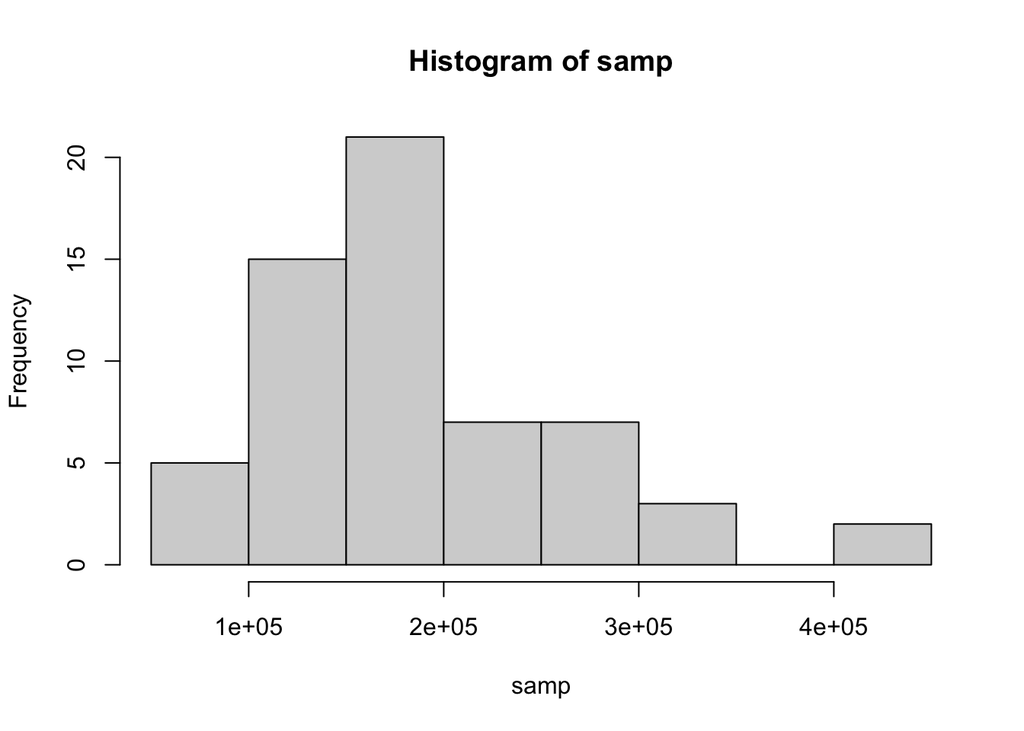

```r
#Calculate a box plot and histogram
hist(samp)
```

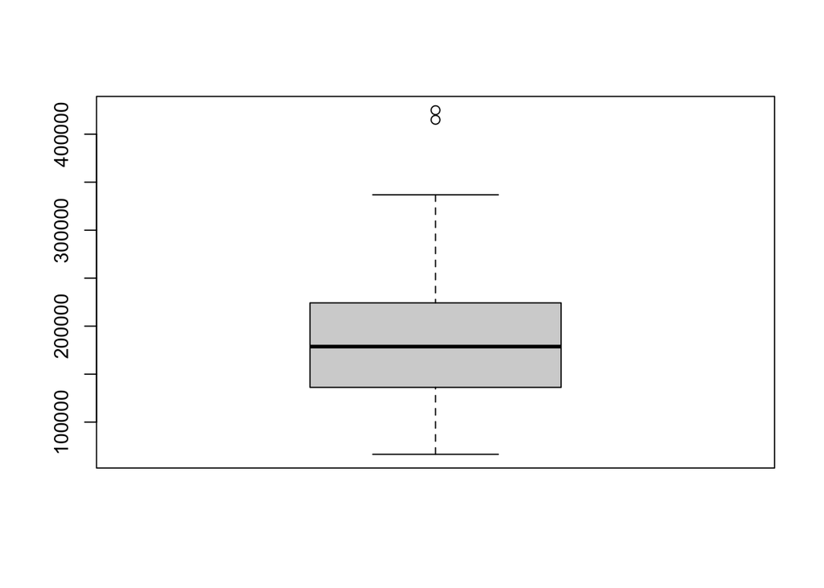

```r
boxplot(samp)
```

# Exercise 2:

Would you expect another student’s distribution to be identical to yours? Would you expect it to be similar? Why or why not?

## Answer:

No! Another student’s distribution will most likely NOT be identical to mine since everyone picked a different **seed** value. This seed value was used to randomly collect a sample from the population dataset. This means that everyone’s sample dataset is different and will result in differing distribution. However, it could be expected that most distributions will be relatively similar some the data comes from the same population dataset.

# Confidence Intervals

A Point Estimate for the true population mean is the sample mean.

```r
# Calculate the sample mean here.
sample_mean = mean(samp)
sample_mean
```

```
## [1] 189541.6
```

We can calculate a 95% confidence interval for the population mean by adding and subtracting the t-score times the standard errors to the point estimate (See Chapter 7).

```r
#Using a Z score

#St error based on the sample standard error - best we can do since true sigma is not known.
#se <- sd(samp) / sqrt(60)
#Confidence_Level = .95

#Zscore = qnorm(.975)

#lower <- sample_mean - Zscore * se
#upper <- sample_mean + Zscore * se
#c(lower, upper)



#Using a student - t
#St error based on the sample standard error - best we can do since true sigma is not known.
sd_xbar <- sd(samp) / sqrt(n)

tscore = qt(.975, df=n-1) # Use .975 for the 95% two sided CI

lower <- sample_mean - tscore * sd_xbar
upper <- sample_mean + tscore * sd_xbar
c(lower, upper)
```

```
## [1] 169958.6 209124.6
```

# Exercise 3:

Why is the t-distribution a better choice than a normal distribution in this case for calculating the CI as described above?

## Answer:

t-distribution is the better choice since the other option requires us to know the true population sigma ($\sigma$). We could use the sample sigma, but it introduces additional uncertainty. So, we must use a t-distribution that will provide a wider interval than the normal distribution to account for this additional uncertainty.

# Exercise 4:

What does “95% confidence” mean?

## Answer:

If you calculate many confidence intervals, $95\%$ of them will contain the true population mean in the long-run.

# Exercise 5.

In this case we have the luxury of knowing the true population mean since we have data on the entire population. This value can be calculated using the following command:

```r
mean(population)
```

```
## [1] 180796.1
```

```r
## [1]  180796.1
```

Does your confidence interval capture the true average size of houses in Ames?

## Answer:

Yes, my confidence interval does capture the true population mean.

# Exercise 6:

Each student in class should have gotten a slightly different confidence interval. What proportion of those intervals would you expect to capture the true population mean? Why?

## Answer:

Roughly $95\%$ will contain the true population mean since we choose a confidence level $95\%$.

# Exercise 7:

Let us demonstrate the answer from Exercise 6. First create 100 different samples of size 60.

We need to first create empty vectors where we can save the sample means and sample standard deviations that will be calculated from each sample. And while we’re at it, let’s also store the desired sample size as n.

```r
samp_mean <- rep(NA, 100) #empty vector for the sample_means
samp_sd <- rep(NA, 100) #empty vector for the sample standard deviations
n <- 60
```

Now we’re ready for the loop where we calculate the means and standard deviations of 100 random samples. The sample(population, n) code creates a sample of size n from the vector we called population. In each iteration of the loop this is a different set of n values. We then calculate the mean and sd of that sample and store it in the vectors we initialized.

```r
set.seed(2078203)

for(i in 1:100){
  samp <- sample(population, n) # obtain a sample of size n = 60 from the population
  samp_mean[i] <- mean(samp)    # save sample mean in ith element of samp_mean
  samp_sd[i] <- sd(samp)        # save sample sd in ith element of samp_sd
}
```

Lastly, we construct the confidence intervals.

```r
lower_vector = samp_mean - qt(.975, n-1)*samp_sd/sqrt(n) # Put in formula for lower value of the Confidence intervals
upper_vector = samp_mean + qt(.975, n-1)*samp_sd/sqrt(n) #Put in the formula for the upper value of the confidence intervals.
#This calculation is doing all 100 calculations at the same time!
#note that .975 = (1+.95)/2 and a general formula for the value needed is (1+ConfidenceLevel)/2
```

Lower bounds of these 100 confidence intervals are stored in lower_vector, and the upper bounds are in upper_vector. Let’s view the first interval.

```r
c(lower_vector[1], upper_vector[1])
```

```
## [1] 169958.6 209124.6
```

Using the `plot_confinv` helper function, plot all intervals. What proportion of your confidence intervals include the true population mean? Is this proportion exactly equal to the confidence level? If not, explain why.

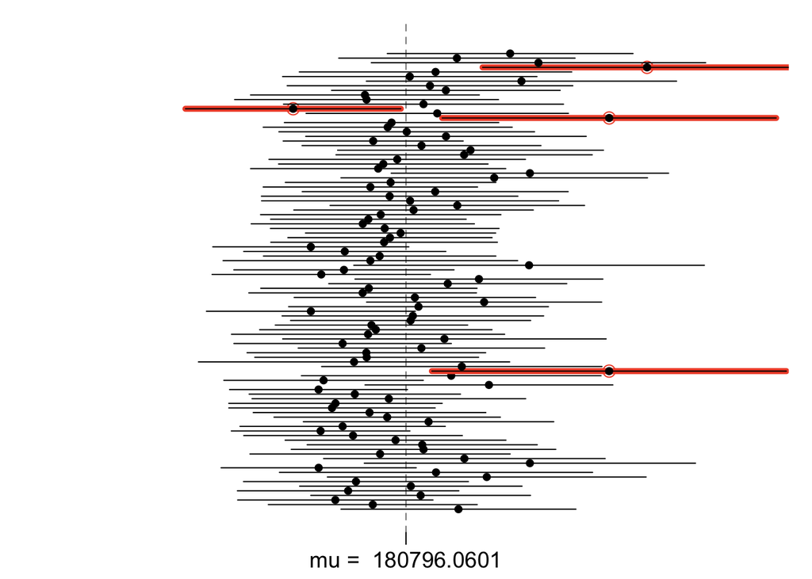

```r
plot_confinv(lower_vector, upper_vector, mean(population),100)
```

## Answer:

From the plotted intervals, there are 4 CIs that do NOT contain the the true population mean — and therefore, 96 of the 100 intervals do containt the true population mean. This is not exactly the equal to the confidence level because the confidence levels is only a probabilty that a single interval will contain it. It could be expected that on average, there would be 5 intervals that don’t contain the true population mean.

# Exercise 8:

Pick a confidence level of your choosing, provided it is not 95%.

For 100 different samples, calculate 100 confidence intervals at the confidence level you choose. You do not need to obtain new samples, simply calculate new intervals based on the sample means and standard deviations you have already collected. Using the `plot_confinv` function, plot all intervals and calculate the proportion of intervals that include the true population mean. How does this percentage compare to the confidence level selected for the intervals?

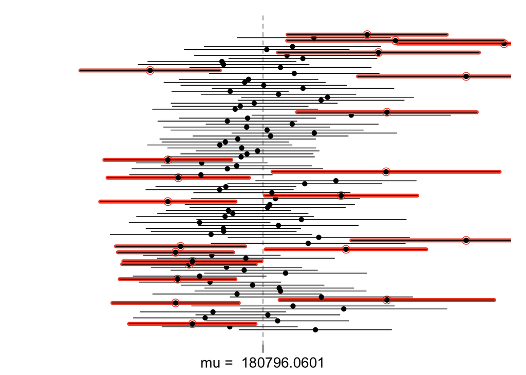

```r
confidence= .80

lower_vector <- samp_mean - qt((1+confidence)/2, n-1) * samp_sd / sqrt(n)
upper_vector <- samp_mean + qt((1+confidence)/2, n-1) * samp_sd / sqrt(n)


plot_confinv(lower_vector, upper_vector, mean(population),100)
```

## Answer:

With a lower confidence level ($.8$), the confidence intervals will be more narrow and as a result, there will be more intervals that don’t contain the true population mean. This is depicted in the plot as there are many red bars. It could be expected for there to be 20 confidence intervals that don’t contain the true population mean in this set of 100 intervals.

# Exercise 9:

Write a few sentence summary describing what you learned in this lab about Confidence intervals.

## Answer:

This lab was a great way to learn about how to apply the theoretical math of confidence intervals to a real world example with a dataset. I also learn how to better work with vectors to perform bulk calculation.